# Resource selection

```r
require(terra)
require(tidyterra)
require(sf)
require(adehabitatHR)
require(adehabitatLT)
require(adehabitatHS)
require(tidyverse)
require(survival)
```

# Quick background

For this lab, we’re going to continue working with radiotelemetry data from Florida panthers (*Puma concolor coryi*) recorded in south Florida. The Florida panther is critically endangered, and there has been a push to understand space use, home ranges, and resource selection. After being collared with radio transmitters, individual panthers are relocated periodically (every 1-3 days) using airplanes. Most of the telemetry locations are recorded during the morning (7:00 am to 12:00 pm) which is a period of time when panthers are typically resting. We’re going to be using data from 6 panthers, 3 of which are adults, and 3 of which are subadults.

Recall that last week we used information on the utilization distributions for these cats to build home ranges using 4 different approaches - minimum convex polygons, kernel density estimates, LoCoH, and Brownian bridge. This week, we’re going to move beyond thinking about the home range, but use the same data to understand resource selection at the point, step, and path levels.

# The data

First we are going to bring in a landcover raster. This landcover map has been aggregated at a 500 m resolution which reflects the approximate grain of telemetry error estimated in this study (489 m). This map was generated by the Florida Fish and Wildlife Commission and contains 43 landcover types, so we’re going to simplify it a bit.

```r
land = rast('https://github.com/ValenteJJ/SpatialEcology/raw/main/Week10/panther_landcover.tif')


classification = read.table('https://raw.githubusercontent.com/ValenteJJ/SpatialEcology/main/Week10/landcover%20reclass.txt', header=T)

head(classification)
```

|  | Landcover | Description | ChangeTo | Description2 |
| --- | --- | --- | --- | --- |
| 1 | 1 | CoastalStrand | 1 | coastalwetland |
| 2 | 2 | Sand | 1 | coastalwetland |
| 3 | 23 | saltmarsh | 1 | coastalwetland |
| 4 | 24 | mangroveswamp | 1 | coastalwetland |
| 5 | 25 | scrubmangrove | 1 | coastalwetland |
| 6 | 26 | tidalflat | 1 | coastalwetland |

```r
unique(classification$Description2)
```

```
##  [1] "coastalwetland"   "Cropland"         "OpenWater"        "PastureGrassland"
##  [5] "Urban"            "Barren"           "Dryprairie"       "Freshwatermarsh"
##  [9] "Scrub/Shrub"      "CypressSwamp"     "Pineland"         "HardwoodSwamp"
## [13] "UplandForest"     "Exotics"
```

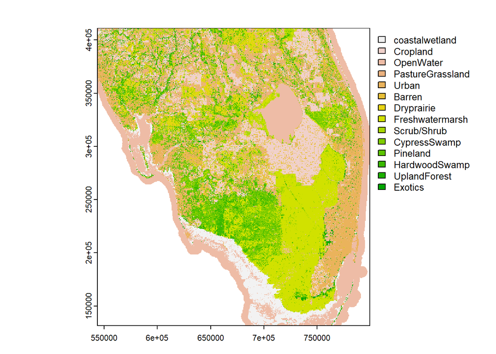

```r
land = classify(land, classification[,c(1,3)])
land = categories(land, value=unique(classification[,c(3,4)]))
plot(land)
```

Now we’re going to bring in the panther telemetry location data. Note that each observation has a X and Y coordinate, an ID for the individual animal, its age class, and a date on which the observation was recorded.

```r
panthers = st_read('/vsicurl/https://github.com/ValenteJJ/SpatialEcology/raw/main/Week10/panthers.shp') %>%
  mutate(CatID = as.factor(CatID))
summary(panthers)
```

```
##        X                Y           CatID        Juldate       AgeClass
##  Min.   :422801   Min.   :2866437   100:127   Min.   :6004   Length:713
##  1st Qu.:457742   1st Qu.:2900017   130: 85   1st Qu.:6093   Class :character
##  Median :470609   Median :2910316   131:118   Median :6186   Mode  :character
##  Mean   :474014   Mean   :2918828   137:131   Mean   :6182
##  3rd Qu.:490659   3rd Qu.:2932481   143:129   3rd Qu.:6268
##  Max.   :516770   Max.   :3042605   147:123   Max.   :6363
##           geometry
##  POINT        :713
##  epsg:NA      :  0
##  +proj=aea ...:  0
##
##
##
```

```r
unique(panthers$CatID)
```

```
## [1] 100 131 137 130 143 147
## Levels: 100 130 131 137 143 147
```

Note that the CRS for the raster and shapefile is the same, so we don’t have to do any spatial transformations. Therefore, we can just plot them on top of one another.

```r
crs(land, proj=T) == crs(panthers, proj=T)
```

```
## [1] TRUE
```